# rel

rel_author

2025-11-08

### Relatório 3 - O Termômetro do Emprego (PNADc)

#### Pergunta-Chave

A taxa de desemprego no Brasil (nacional) se move da mesma forma que nas Grandes Regiões? Existem diferenças estruturais (níveis) entre elas?

#### Descrição dos Dados

Voltamos ao sidra (IBGE) para buscar dados da PNAD Contínua. Usaremos a Tabela 4093, com os dados diretamente do IBGE. Pela página SIDRA. https://sidra.ibge.gov.br/. A tabela 4093 mede a taxa de desocupação (desemprego) por trimestre, tanto para o Brasil quanto para as Grandes Regiões. https://sidra.ibge.gov.br/tabela/4093

Outra forma de consumir esse dado seria pelo pacote em R, chamado *sidrar*. Informações sobre o pacote estão disponíveis em: https://cran.r-project.org/web/packages/sidrar/index.html

Vamos mostrar os códigos e os resultados. Para esconder os códigos do resultado, colocar *echo = FALSE*. Observar primeiro bloco de código abaixo com essa propriedade inserida.

Bloco de código 1. Carregamento de pacotes (omitido)

Bloco de código 2. Carregamento de dados

```r
# 2. Carga de dados - arquivo no Temp

#### ajustar caminho da pasta - EXEMPLO: '/cloud/project/'

dados_brutos_pnad <- readxl::read_excel('C:\\mark\\projetos\\oficina_r_mackrio\\tabela4093.xlsx',
                                        col_types = "text")
# observar dados parciais para identificar dados baixados
dplyr::tibble(head(dados_brutos_pnad))
```

```
## # A tibble: 6 × 3
##   Tabela 4093 - Pessoas de 14 anos ou mais de idade, total, na for…¹ ...2  ...3
##   <chr>                                                              <chr> <chr>
## 1 Variável - Taxa de desocupação, na semana de referência, das pess… <NA>  <NA>
## 2 Grande Região                                                      Trim… Sexo
## 3 <NA>                                                               <NA>  Total
## 4 Norte                                                              1º t… 9.0
## 5 <NA>                                                               2º t… 8.2
## 6 <NA>                                                               3º t… 7.9
## # ℹ abbreviated name:
## #   ¹`Tabela 4093 - Pessoas de 14 anos ou mais de idade, total, na força de trabalho, ocupadas, desocupadas, fora da força de trabalho, em situação de informalidade e respectivas taxas e níveis, por sexo`
```

Bloco de código 3. Limpeza de dados

```r
# 3. Limpeza dos Dados
# A limpeza aqui é um pouco mais complexa com a data (trimestres)
pnad_limpo <- dados_brutos_pnad %>%
  slice(-c(1:3,n())) %>%
  rename(regiao = 1,trimestre_str=2,taxa_desemprego=3) %>%
  # Converter taxa para numérico
  mutate(taxa_desemprego = as.numeric(taxa_desemprego)) %>%

  # Converter a string "1ª Trimestre de 2025" Pegar (Ano + Trimestre) em uma data
  mutate(
    ano = as.numeric(str_sub(trimestre_str, -4, -1)),
    tri = as.numeric(str_sub(trimestre_str, 1, 1)),
    data = lubridate::make_date(ano, tri, 1) # Função do lubridate
  ) %>%
  # preencher valores da regiao - tidyr::fill()
  fill(regiao) %>%

  # Remover NAs que podem ter sido gerados
  filter(!is.na(taxa_desemprego), !is.na(data))

# observar dados parciais para identificar dados baixados
dplyr::tibble(head(pnad_limpo))
```

```
## # A tibble: 6 × 6
##   regiao trimestre_str     taxa_desemprego   ano   tri data
##   <chr>  <chr>                       <dbl> <dbl> <dbl> <date>
## 1 Norte  1º trimestre 2012             9    2012     1 2012-01-01
## 2 Norte  2º trimestre 2012             8.2  2012     2 2012-02-01
## 3 Norte  3º trimestre 2012             7.9  2012     3 2012-03-01
## 4 Norte  4º trimestre 2012             7.4  2012     4 2012-04-01
## 5 Norte  1º trimestre 2013             8.7  2013     1 2013-01-01
## 6 Norte  2º trimestre 2013             8.4  2013     2 2013-02-01
```

Bloco de código 4. Cálculo da média para análise

```r
# 4. Cálculo das Medidas
# Vamos calcular a taxa média de desemprego por região no período total
media_por_regiao <- pnad_limpo %>%
  group_by(regiao) %>%
  summarise(
    media_desemprego_periodo = mean(taxa_desemprego, na.rm = TRUE)
  )

# Vamos calcular a taxa média de desemprego por região em 2025
media_por_regiao_2025 <- pnad_limpo %>%
  filter(year(data) == '2025') %>%
  group_by(regiao) %>%
  summarise(
    media_desemprego_periodo = mean(taxa_desemprego, na.rm = TRUE)
  )


df_media <- tibble(`Grande Região` = media_por_regiao$regiao,
                   `Média no período` = media_por_regiao$media_desemprego_periodo,
                   `Média em 2025` = media_por_regiao_2025$media_desemprego_periodo)

print(df_media)
```

```
## # A tibble: 5 × 3
##   `Grande Região` `Média no período` `Média em 2025`
##   <chr>                        <dbl>           <dbl>
## 1 Centro-Oeste                  7.54            5
## 2 Nordeste                     11.8             9.05
## 3 Norte                         9.45            7.35
## 4 Sudeste                       9.39            5.95
## 5 Sul                           5.86            3.9
```

Acima temos a Tabela com a taxa média de desemprego. No Nordeste temos a maior média da taxa de desemprego entre as regiões. O ano de 2025 têm valores menores que a média histórica em todas as regiões.

Bloco de código 5. Visualização inicial

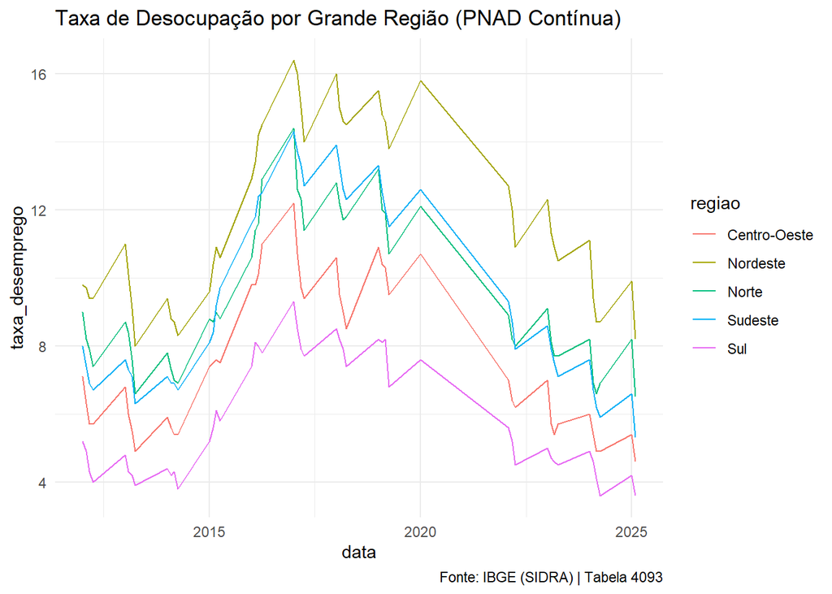

```r
# Os dados para o gráfico já estão prontos em 'pnad_limpo'
pnad_final_plot <- pnad_limpo


# 5. Visualização dos Resultados
ggplot(pnad_final_plot, aes(x = data, y = taxa_desemprego, color = regiao)) +
  geom_line() +
  labs(
    title = "Taxa de Desocupação por Grande Região (PNAD Contínua)",
    caption = "Fonte: IBGE (SIDRA) | Tabela 4093"
  ) +
  theme_minimal()
```

Bloco de código 6. Visualização para análise

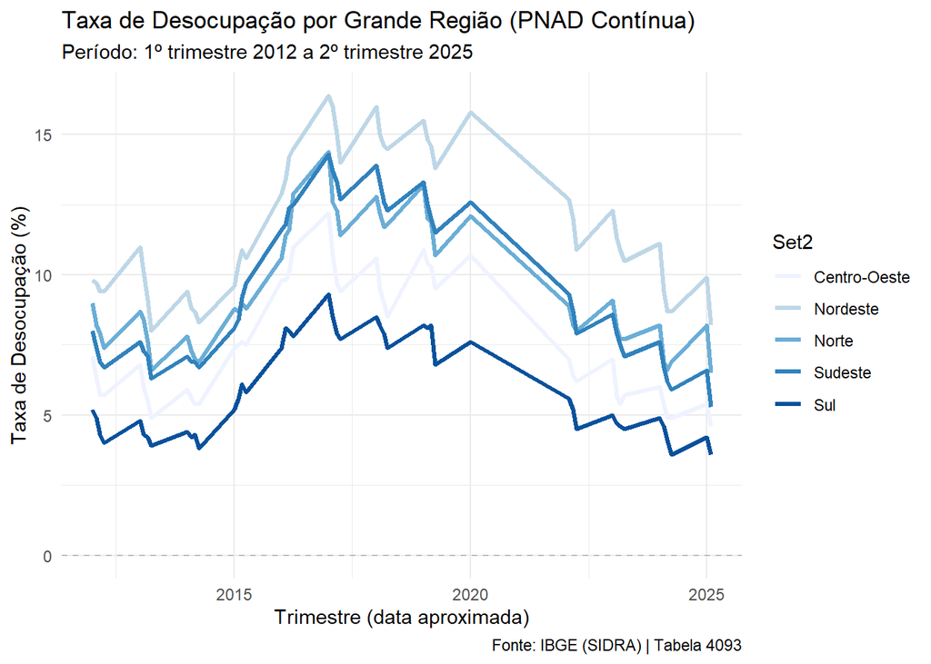

```r
# 5. Visualização dos Resultados
ggplot(pnad_final_plot, aes(x = data, y = taxa_desemprego, color = regiao)) +
  geom_line(linewidth = 1.1) +
  scale_color_brewer("Set2") +
  geom_hline(yintercept = 0, linetype = "dashed", color = "gray") +
  labs(
    title = "Taxa de Desocupação por Grande Região (PNAD Contínua)",
    subtitle = "Período: 1º trimestre 2012 a 2º trimestre 2025",
    y = "Taxa de Desocupação (%)",
    x = "Trimestre (data aproximada)",
    color = "Região",
    caption = "Fonte: IBGE (SIDRA) | Tabela 4093"
  ) +
  theme_minimal()
```